# Jamboree-Education- Linear-Regression

# Finding Optimum weights using Gradient Descent

```python
def hypothesis(x,weights):
    y_hat = np.dot(x,weights)
    return y_hat

def error(X,Y,weights):
    e=0.0
    m = X.shape[0]
    y_hat = hypothesis(X,weights)
    e = np.sum((Y-y_hat)**2)
    return e/m

def gradient(X,Y,weights):
    y_hat = hypothesis(X,weights)
    grad = np.dot(X.T,(y_hat-Y))
    m = X.shape[0]

    return grad/m

def gradient_descent(X,Y,lr=0.1,epoches=1000):
    m = X.shape[1]
    weights = np.zeros((m,))
    error_list = []

    for i in range(epoches):
        e = error(X,Y,weights)
        error_list.append(e)

        grad = gradient(X,Y,weights)

        weights = weights - lr * grad
    return weights,error_list



def adj_r2_score(r2_score,xtest,ytest):
    num = (1-r2_score)*(len(ytest)-1)
    denom = len(ytest)-xtest.shape[1]-1
    adjr2_sq = 1-(num/denom)
    return adjr2_sq
```

```python
weights,error_list = gradient_descent(xtrain,ytrain,lr=0.01)
```

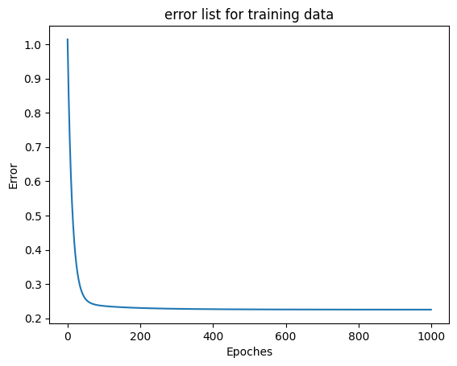

```python
plt.title('error list for training data')
plt.plot(error_list)
plt.xlabel('Epoches')
plt.ylabel('Error')
plt.show()
```

```python
from sklearn.metrics import r2_score
```

```python
y_pred_gd = hypothesis(xtest,weights)
```

```python
print(f' r2_score : {r2_score(ytest,y_pred_gd)}')
print(f' adj_r2_score : {adj_r2_score(r2_score(ytest,y_pred_gd),xtest,ytest)}')
```

```
 r2_score : 0.7321025000510855
 adj_r2_score : 0.7160744444985863
```

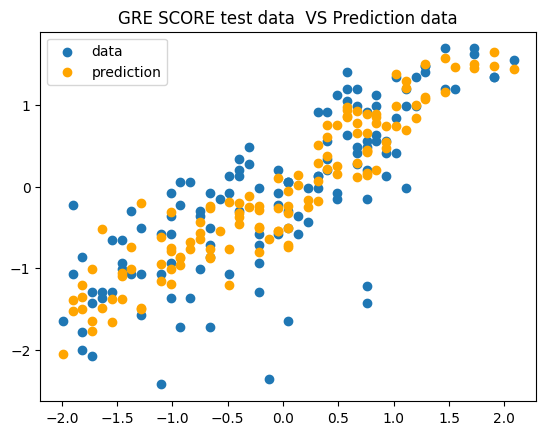

```python
fig = plt.figure()
plt.title('GRE SCORE test data  VS Prediction data')
plt.scatter(xtest['GRE Score'],ytest,label='data')
plt.scatter(xtest['GRE Score'],y_pred_gd,color='orange',label='prediction')
plt.legend()
plt.show()
```

# Assumptions test of linear regression

# Assumption 1: Residuals are independent of each other.

# Assumption 2: Residuals should have a constant variance.

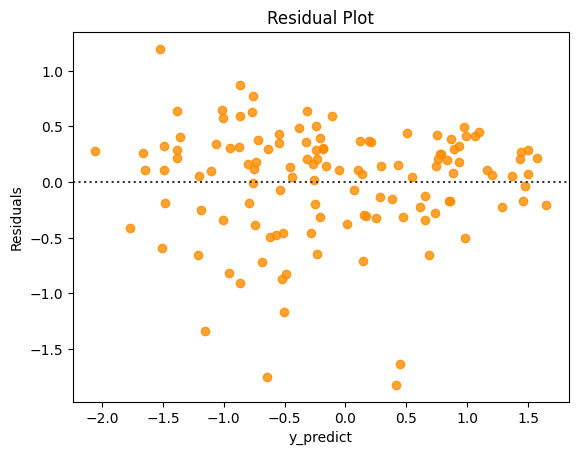

```python
residual_gd = ytest-y_pred_gd
sns.residplot(x=y_pred_gd,y=residual_gd,color='darkorange')
plt.xlabel("y_predict")
plt.ylabel("Residuals")
plt.title("Residual Plot")
plt.show()
```

From the above residual plot, we could infer that the residuals didn’t form any pattern. So, the residuals are independent of each other.

And also, the residuals have constant variance. Variance doesn’t seem to increase/decrease constantly with the y_predict value.

# Assumption 3: Residuals are normally distributed

To check whether the residuals are normally distributed from Q-Q plot,distplot

Q-Q plot → quantile-quantile plot If the residuals are normally distributed, then the Q-Q plot of residuals will be a straight line

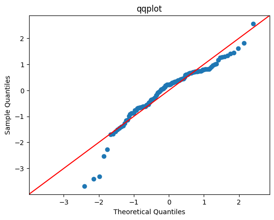

```python
from scipy import stats
probplot=sm.ProbPlot(residual_gd,stats.norm,fit=True)
fig=probplot.qqplot(line='45')
plt.title('qqplot')
plt.show()
```

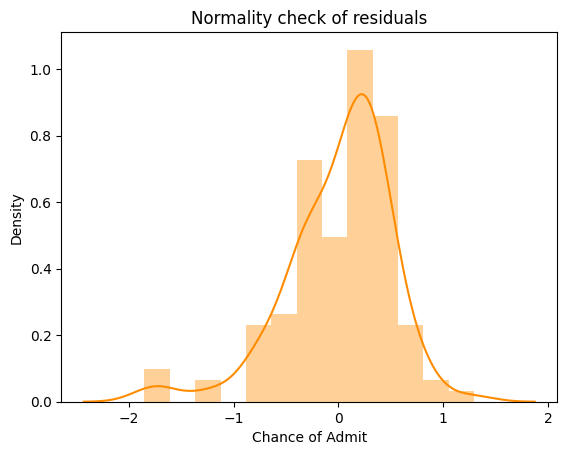

```python
plt.title('Normality check of residuals')
sns.distplot(residual_gd,color='darkorange')
plt.show()
```

# Mean of Residuals

```python
mean_of_residual_gd = np.mean(residual_gd)
print(f'mean_of_residual :{mean_of_residual_gd}')
```

```
mean_of_residual :0.004759225283660022
```

# Test for Homoscedasticity

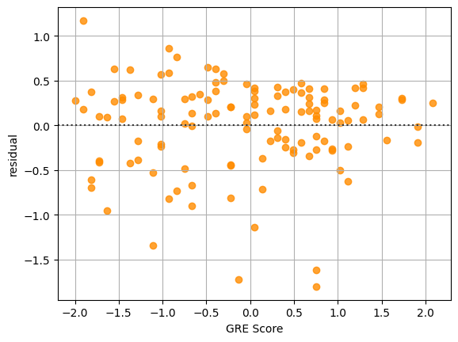

```python
sns.residplot(x=xtest['GRE Score'],y=residual_gd,color='darkorange')
plt.grid()
plt.ylabel('residual')
plt.show()
```

# Training linear regression model using statsmodel

```python
model_sm = sm.OLS(ytrain, xtrain).fit()
```

```python
print(f'adjusted r2_Score : {model_sm.rsquared_adj}')
print(f'r2_Score : {model_sm.rsquared}')
```

```
adjusted r2_Score : 0.7740871252650812
r2_Score : 0.7777113959827536
```

```python
y_pred_sm = model_sm.predict(xtest)
```

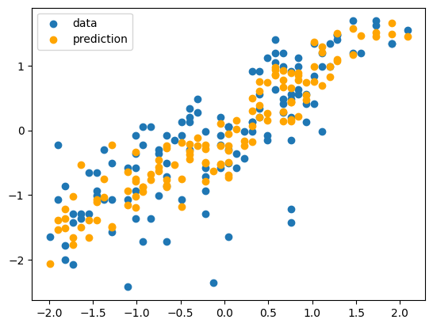

```python
fig = plt.figure()
plt.scatter(xtest['GRE Score'],ytest,label='data')
plt.scatter(xtest['GRE Score'],y_pred_sm,color='orange',label='prediction')
plt.legend()
plt.show()
```

# Assumptions test of linear regression

# Assumption 1: Residuals are independent of each other.

# Assumption 2: Residuals should have a constant variance.

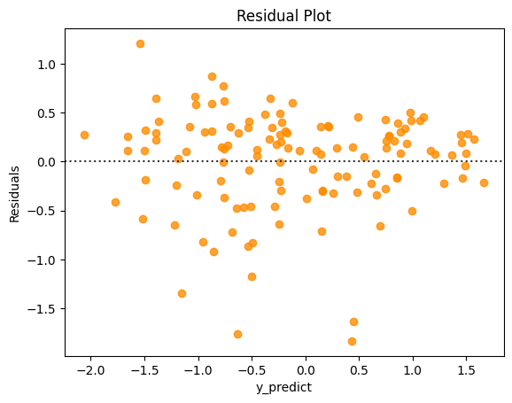

```python
residual_stats_model = ytest-y_pred_sm
sns.residplot(x=y_pred_sm,y=residual_stats_model,color='darkorange')
plt.xlabel("y_predict")
plt.ylabel("Residuals")
plt.title("Residual Plot")
plt.show()
```

From the above residual plot, we could infer that the residuals didn’t form any pattern. So, the residuals are independent of each other.

And also, the residuals have constant variance. Variance doesn’t seem to increase/decrease constantly with the y_predict value.

# Assumption 3: Residuals are normally distributed

To check whether the residuals are normally distributed from Q-Q plot,distplot

Q-Q plot → quantile-quantile plot If the residuals are normally distributed, then the Q-Q plot of residuals will be a straight line

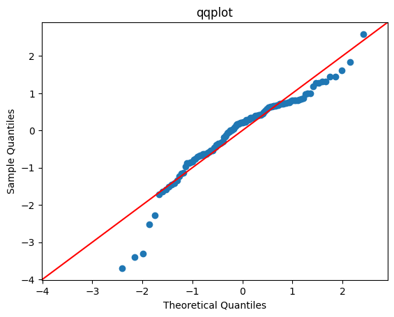

```python
probplot=sm.ProbPlot(residual_stats_model,stats.norm,fit=True)
fig=probplot.qqplot(line='45')
plt.title('qqplot')
plt.show()
```

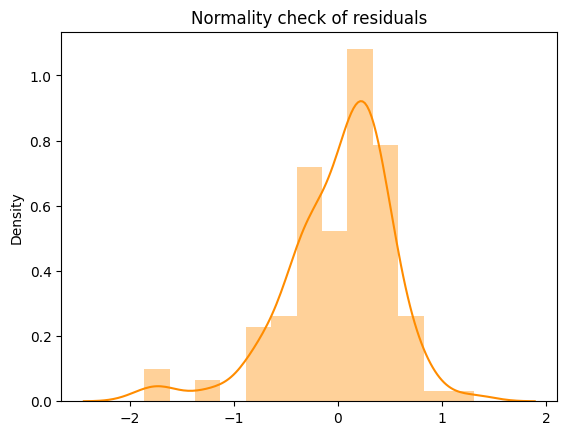

```python
plt.title('Normality check of residuals')
sns.distplot(residual_stats_model,color='darkorange')
plt.show()
```

# Mean of Residuals

```python
mean_of_residual_sm = np.mean(residual_stats_model)
print(f'mean_of_residual :{mean_of_residual_sm}')
```

```
mean_of_residual :0.004515713914597043
```

# Test for Homoscedasticity

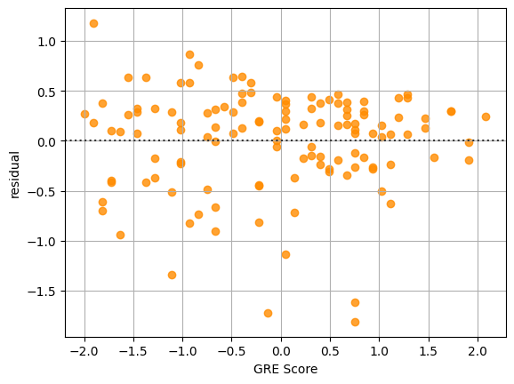

```python
sns.residplot(x=xtest['GRE Score'],y=residual_stats_model,color='darkorange')
plt.grid()
plt.ylabel('residual')
plt.show()
```

# Training model using Scikit learn linear Regression algorithm

```python
from sklearn.linear_model import LinearRegression
```

```python
model = LinearRegression()
```

```python
model.fit(xtrain,ytrain)
```

```
LinearRegression()
```

```python
ypred_linear_model = model.predict(xtest)
```

```python
print(f'r2_score of train data : {model.score(xtrain,ytrain)}')

print(f'r2_score of test data : {model.score(xtest,ytest)}')

print(f'adj_r2_score : {adj_r2_score(r2_score(ytest,ypred_linear_model),xtest,ytest)}')
```

```
r2_score of train data : 0.7777113959827537
r2_score of test data : 0.7304425298547268
adj_r2_score : 0.7143151598460352
```